# One Command Line Plot - Scatter Plot

Walter Xie

09/02/2017

## Introduction

One of the feature of [**ComMA**](http://github.com/walterxie/ComMA) package is to simplify [ggplot2](http://docs.ggplot2.org/current/) codes into one-line functions, and also to provide some other useful utility functions.

```r
library(ComMA)
#getwd()
```

## Scatter plot

Create random coordinates for 2 clusters:

```r
df.clusters <- random2Clusters()
df.clusters$labels <- rownames(df.clusters)
df.clusters[1:3,]
```

```
##          x        y group labels
## 1 1.673964 2.437651     A      1
## 2 2.552462 1.928776     A      2
## 3 1.325056 4.163509     A      3
```

Scatter plots may have overlaps between data points and axises. `unclip.ggplot` can turns off clipping, but it returns a *gtable* object, so that either `pdf.gtplot` or `plot.gtable` will be used to handle the plot.

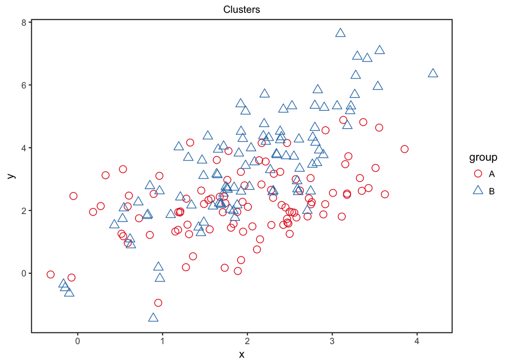

```r
gg.plot <- ggScatterPlot(df.clusters, x.id="x", y.id="y", colour.id="group", shape.id="group",
                         title="Clusters", palette="Set1", verbose=F)
# turns off clipping
g.table <- unclip.ggplot(gg.plot)
plot(g.table)
```

### Some tricks

`ellipsed.id=“group”` creates ellipses by groups, `text.id=“labels”` defines the column for labels, `xintercept=0 and yintercept=0` sets the coordinate axes, and `text.data=subset(df.clusters, x > 3 & y > 6)` selectively labels the points at x > 3 and y > 6:

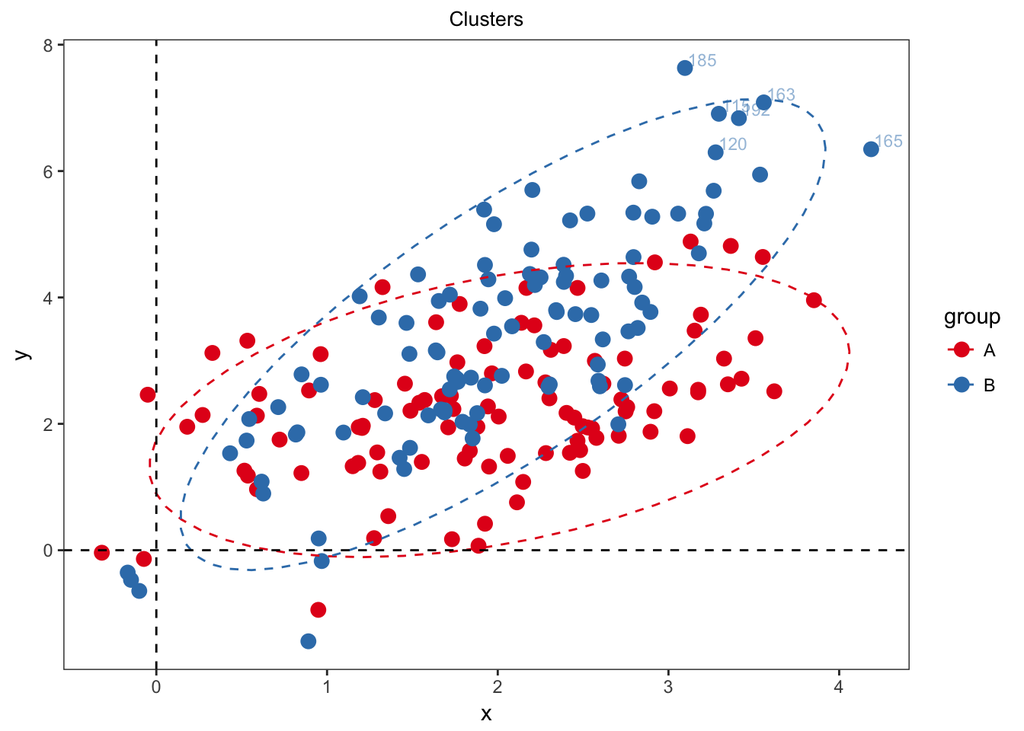

```r
# selective labeling for points x > 3 and y > 6
ggScatterPlot(df.clusters, x.id="x", y.id="y", colour.id="group", ellipsed.id="group", text.id="labels",
              text.data=subset(df.clusters, x > 3 & y > 6), xintercept=0, yintercept=0,
              title="Clusters", palette="Set1", verbose=F)
```